# Lecture 1b

Vaishali Chaudhuri

April 3, 2015

# What is Github

- Github is like a mini filesystem with powerful tools of version control built in
- Git thinks of its data more like a set of snapshots of a miniature filesystem.
- Most operations in Git only need local files and resources to operate
- When you do actions in Git, nearly all of them only add data to the Git database. It is hard to erase data in any way

# The Three States

Git has three main states that your files can reside in:

- Committed means that the data is safely stored in your local database
- Modified means that you have changed the file but have not committed it to your database yet
- Staged means that you have marked a modified file in its current version to go into your next commit snapshot

This leads us to the three main sections of a Git project: the Git directory, the working directory, and the staging area.

# How to install git on computer

- In Mac
  - GitHub has a Mac client! You can use it without ever touching the command line.
- In Windows
- Download and install the latest version of Git.
- On your computer, open the Terminal application.
- Tell Git your name so your commits will be properly labeled. Type everything after the $ here:

```
$ git config --global user.name "YOUR NAME"
```

-Associate the email address that will be associated with your Git commits. Keep your email address setting as private.

```
$ git config --global user.email "YOUR EMAIL ADDRESS"
```

# Next steps: Authenticating with GitHub from Git

- When you connect to a GitHub repository from Git, you’ll need to authenticate with GitHub using either HTTPS or SSH.
- Connecting over HTTPS (recommended)
- If you clone with HTTPS, you can cache your GitHub password in Git using a credential helper.
- Connecting over SSH

_ If you clone with SSH, you must generate SSH keys on each computer you use to push or pull from GitHub.

# How to create a repo

On GitHub, one can store all kinds of projects in repositories.

-Personal repositories belong to user accounts, after you’ve signed up for GitHub, create your first repository!

- In the upper-right corner of you account page click- New repository
- Create a short, memorable name for your repository. For example, “hello-world”.
- Choose between creating a public or private repository.
- Public repositories are a great choice and visible to any user on GitHub, so you can benefit from a collaborative community.
- Private repositories are only available for paid accounts only available to you, the repository owner.

# Commit your first change

A commit is like a snapshot of all the files in your project at a particular point in time.

- README files are a great place to describe your project in more detail, or add some documentation such as how to install or use your project.
- The contents of your README file are automatically shown on the front page of your repository.

Let’s commit a change to the README file.

# Commit changes (contd.)

Congratulations! You have now created a repository, including a README file, and created your first commit on GitHub.

# Introducing concepts in LaTeX document

- Why write in LaTeX?
  - Pros (why prepare presentations using LaTeX):
    - The software for preparing the presentation is free.
    - The outcome is platform-independent: you can display PDF documents pretty much with any OS.
    - You get the typographic advantages of LaTeX, especially in typesetting of text and mathematics.
  - Cons (why you might prefer MS Powerpoint/Word):
    - If you have no or very little math, the advantages of LaTeX becomes less critical.
    - Some aspects of animations may be admittedly harder to create with LaTeX
    - It is (yet) impossible to embed movies or sound in the PDF presentation

# Write a document with in LaTeX using scientific concepts

Typesetting mathematics is one of LaTeX’s greatest strengths.

- If your document requires only a few simple mathematical formulas, plain LaTeX has most of the tools that you will need.
- If you are writing a scientific document that contains numerous complicated formulas, the ‘amsmath’ package introduces several new commands that are more powerful and flexible than the ones provided by LaTeX.

# Literate Calculation Exercise

- Use simple $\LaTeX$ formatting to typeset a mathematical equation in an RMarkdown document.
- check out (calcCheck1.RMD/pdf) as an example of Latex scientific document for homework: https://github.com/rmhorton/statprog/tree/master/week_01_teach_yourself_R
- check out how to write more Mathematical font at:

http://en.wikibooks.org/wiki/LaTeX/Mathematics

# What would this function do

What does this function do?

```r
function(N) {
  x <- runif(N)
  y <- runif(N)
  4 * sum( (x^2 + y^2) < 1 )/N
}
```

- How would you give this function a name?

# Solution to the previous problem

- start of by making two uniformly distributed random numbers x and y
- ((x^2 + y^2) < 1 ) -This expression depicts the square of each x and y such that the square of them is less than 1
- Geometrically thinking on a graph this represents random points on the graph whose sum of squares is going to be less than 1 .
- (sqrt(x^2 +y^2) < 1)-The square root of the (sum( (x^2 + y^2)) will give distance of x and y vector from point zero.
- ((x^2 + y^2) < 1 ). This gives a logical vector _ sum of logical vector coerces a logical vector into true and false and in this case tells if the distance of a point from zero is less than 1 or not

# Soln to the problem continued…

- Multiplication by 4 gives the representation in all the four quadrants from distance 0,0 as each quadrant is a mirror image of each other
- Division by N gives the ratio of points in a unitcircle inside a unit square $r = 1$ $A_{circle} = 4* \pi r^2$ $A_{square} = (2 r) ^ 2 = 4r^2$ $4* \pi r^2 / 4r^2 = \pi$ Therefore this function can be named
- How to approximately estimate value of Pi

# Homework Exercise

```r
function(N) {
  x <- runif(N)
  y <- runif(N)
  4 * sum( (x^2 + y^2) < 1 )/N
}
```

- What is the type of the parameter `N`? (hint: see `?runif`)
- How can you call this function to see what happens?
- What is the type of the argument to `sum()`?

# Homework Exercise Review

What will this code show?

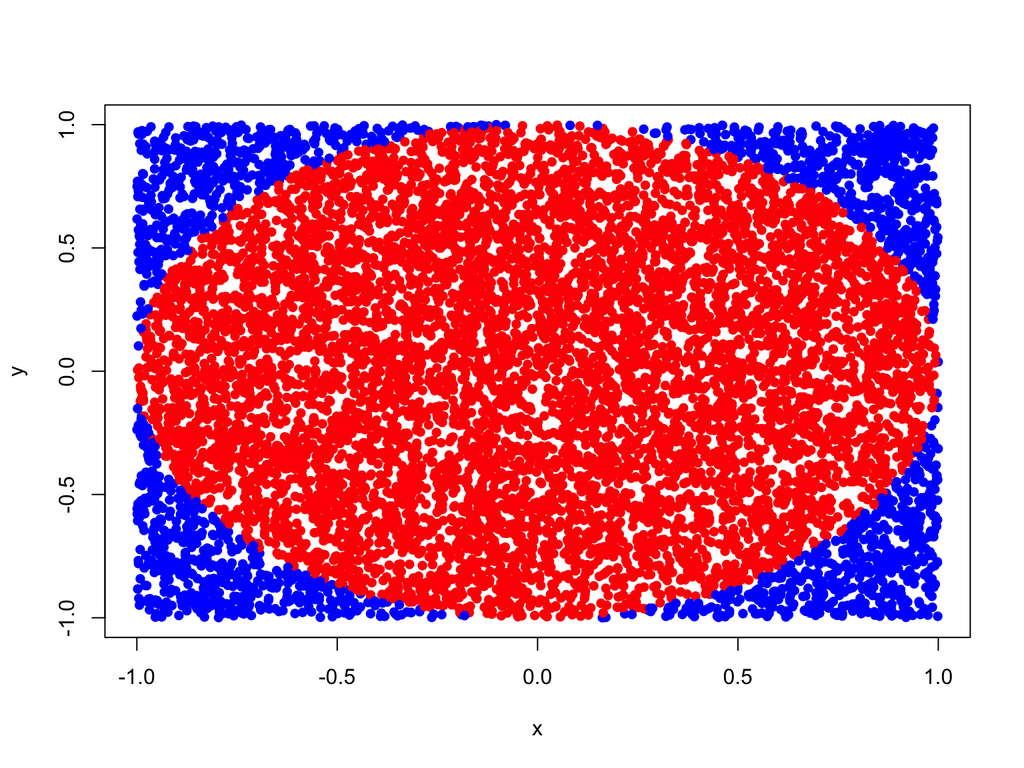

```r
N <- 10000
x <- runif(N, min=-1.0, max=1.0)
y <- runif(N, min=-1.0, max=1.0)
plot(x, y, pch=16, col=ifelse(x^2 + y^2<1, "red", "blue"))
```

# Homework Exercise Review

What will this code show?

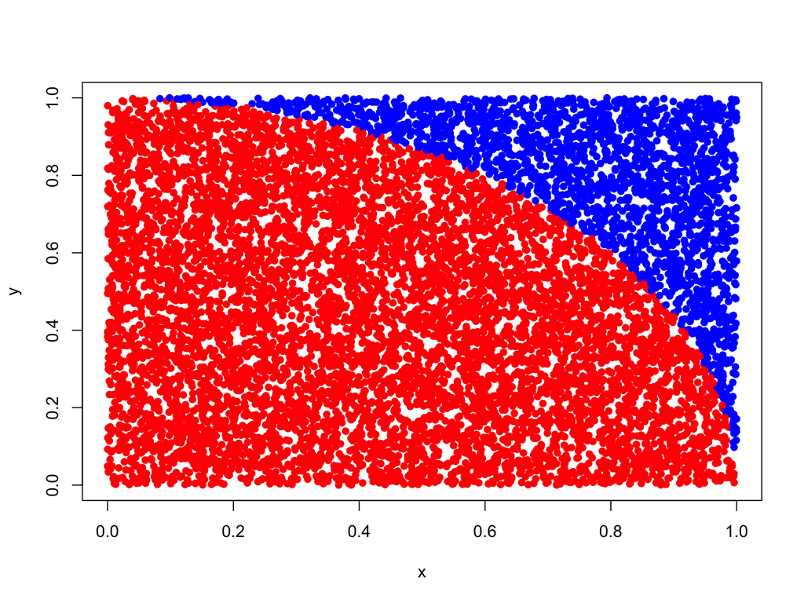

```r
N <- 10000
x <- runif(N)
y <- runif(N)
plot(x, y, pch=16, col=ifelse(x^2 + y^2<1, "red", "blue"))
```

# Homework Exercise Review

What will this code show?

```r
estimate_pi <- function(N) {
    x <- runif(N)
    y <- runif(N)
  4 * sum( (x^2 + y^2) < 1 )/N
}
estimate_pi(100000)
```

```
## [1] 3.14476
```